# How should we aggregate ratings on SWARM?

### Lizzie Silver

### SWARM Lunchtime Talk, 21/11/2017

## Outline:

1. What's wrong with the average?
2. Why we can't have nice things
3. Methods I am testing (and the ones I'm not)
4. How I create fake data
5. How I'm evaluating performance (and how I'm not)
6. Results: what makes a difference (and what doesn't)
7. So ... help me decide already

## Two things we want from rating aggregation

1. Elicit raters' honest opinions
2. Don't give one rater more power than another

## What's wrong with the average?

1. Users give extreme (insincere) scores to "push" an answer up or down
2. Raters who give extreme scores have more influence than raters who give moderate scores

## Alternatives to the average

Extreme scores are a sensible strategy, given the incentives!

How can we remove the incentive to rate dishonestly?

Rank aggregation?

## Why we can't have nice things: the original

Arrow's Impossibility Theorem:

1. **Pareto:** If every voter prefers alternative X over alternative Y, then the group prefers X over Y.
2. **Independence of irrelevant alternatives:** If every voter's preference between X and Y remains unchanged, then the group's preference between X and Y will also remain unchanged (even if voters' preferences between other pairs like X and Z, Y and Z, or Z and W change).
3. **No "dictator":** no single voter possesses the power to always determine the group's preference.
4. **Unrestricted domain:** Voters can express any coherent order of preference.

Arrow showed that we can't have all four at once.

## Why we can't have nice things: the remix

Gibbard-Satterthwaite Theorem:

1. **No "dictator":** no single voter possesses the power to always determine the group's preference.
2. **Three or more options:** Works when you have more than two options being ranked
3. **Strategy-proof:** For all voters, the outcome they get when they vote with their true preferences *P*, is at least as good or better than outcome they would get if they voted with any other ordering *P'*. In other words, no voter can do better by voting dishonestly.

Gibbard and Satterthwaite showed you can't have all three at once.

## Some strategies take more work

"Give extreme scores" is easy and predictable.

If a system fails "independence of irrelevant alternatives", I might be able to reverse the order of *A* and *B* by changing my ranking of *C* and *D* ... or *E* and *F* ...

Space of possible rankings is large:

| # of items | # of partial rankings |
| --- | --- |
| 2 | 3 |
| 3 | 13 |
| 4 | 75 |
| 5 | 541 |
| 6 | 4683 |
| 7 | 47293 |
| 8 | 545835 |
| 9 | 7087261 |
| 10 | 102247563 |

## The new goal

1. Don't give one rater more power than another
2. Make it *hard work* for a rater to rate dishonestly.
   - Hard to see how to game the system
   - Honest preferences should do pretty well

## Methods I am testing:

1. Mean (status quo)
2. RdR Ranking
3. Borda Count
4. User Preferences Ranking
5. Anca Ranking

## Methods I am NOT testing:

1. Use lower bound of confidence interval around the mean (or Bayesian credible interval, etc.)
   - Can still be gamed by giving extreme scores
2. Minimum violation ranking. It's the optimal rank aggregation method (according to Langville & Meyers), but:
   - Complex to implement
   - Non-polynomial runtime
   - Not well suited to partial rankings

## RdR Ranking

1. Rank by average score
2. Move the answers with more than one rating above the answers with only one rating

## Borda Count

Invented by Jean-Charles de Borda in 1770

1. For each rater, take their ranked list of answers, and for each answer on the list, count how many other answers it *outranks*
2. For each answer, sum these counts across all raters

My tweak: give each rating a 1-point boost for being rated at all

Example input:

|  | $a_1$ | $a_2$ | $a_3$ | $a_4$ | $a_5$ |
| --- | --- | --- | --- | --- | --- |
| $u_1$ | 3 |  |  | 5 | 1 |
| $u_2$ | 1 | 4 | 4 | 6 |  |
| $u_3$ | 3 |  | 2 | 3 |  |
| $u_4$ | 1 | 4 |  | 5 | 1 |

Counts matrix:

|  | $a_1$ | $a_2$ | $a_3$ | $a_4$ | $a_5$ |
| --- | --- | --- | --- | --- | --- |
| $u_1$ | 2 |  |  | 3 | 1 |
| $u_2$ | 1 | 2 | 2 | 4 |  |
| $u_3$ | 2 |  | 1 | 2 |  |
| $u_4$ | 1 | 3 |  | 4 | 1 |

Final score vector gives a ranking of 4, 1, 2, 3, 5

| $a_1$ | $a_2$ | $a_3$ | $a_4$ | $a_5$ |
| --- | --- | --- | --- | --- |
| 6 | 5 | 3 | 13 | 2 |

## User Preferences Ranking

Described in Ch 10 of *Who's #1?* by Langville & Meyer

1. For each pair of answers, get a pairwise difference score:
   1. Take the set of raters who have rated both of them
   2. Sum the "point differences" and divide by the number of raters
2. For each answer, sum its pairwise differences with all the other answers

Example input:

|  | $a_1$ | $a_2$ | $a_3$ | $a_4$ | $a_5$ |
| --- | --- | --- | --- | --- | --- |
| $u_1$ | 3 |  |  | 5 | 1 |
| $u_2$ | 1 | 4 | 4 | 6 |  |
| $u_3$ | 3 |  | 2 | 3 |  |
| $u_4$ | 1 | 4 |  | 5 | 1 |

Pairwise differences matrix:

|  | $a_1$ | $a_2$ | $a_3$ | $a_4$ | $a_5$ |
| --- | --- | --- | --- | --- | --- |
| $a_1$ | 0 | 3 | 1 | 2.75 | -1 |
| $a_2$ | -3 | 0 | 0 | 1.5 | -3 |
| $a_3$ | -1 | 0 | 0 | 1.5 | 0 |
| $a_4$ | -2.75 | -1.5 | -1.5 | 0 | -4 |
| $a_5$ | 1 | 3 | 0 | 4 | 0 |

Final score vector gives a ranking of 4, 2, 3, 1, 5

| $a_1$ | $a_2$ | $a_3$ | $a_4$ | $a_5$ |
| --- | --- | --- | --- | --- |
| -5.75 | 4.5 | -0.5 | 9.75 | -8 |

## Anca rating:

Like User Preferences, but instead of using the point differences, just use the "win-loss" ratio.

Example input:

|  | $a_1$ | $a_2$ | $a_3$ | $a_4$ | $a_5$ |
| --- | --- | --- | --- | --- | --- |
| $u_1$ | 3 |  |  | 5 | 1 |
| $u_2$ | 1 | 4 | 4 | 6 |  |
| $u_3$ | 3 |  | 2 | 3 |  |
| $u_4$ | 1 | 4 |  | 5 | 1 |

Pairwise differences matrix:

|  | $a_1$ | $a_2$ | $a_3$ | $a_4$ | $a_5$ |
| --- | --- | --- | --- | --- | --- |
| $a_1$ | 0 | 1 | 0 | 0.75 | -0.5 |
| $a_2$ | -1 | 0 | 0 | 1 | -1 |
| $a_3$ | 0 | 0 | 0 | 1 | 0 |
| $a_4$ | -0.75 | -1 | -1 | 0 | -1 |
| $a_5$ | 0.5 | 1 | 0 | 1 | 0 |

Final score vector gives a ranking of 4, 2, 3, 1, 5

| $a_1$ | $a_2$ | $a_3$ | $a_4$ | $a_5$ |
| --- | --- | --- | --- | --- |
| -1.25 | 1 | -1 | 3.75 | -2.5 |

## Strategy for evaluation

1. Create fake, semi-realistic ratings data where I know the "true quality" of each answer
2. Run the aggregation functions on the data (Mean, RdR Ranking, Borda Count, User Preferences, and Anca Ranking)
3. Compare the ordering of "true quality" with the ordering produced by the five methods

## How I create fake data

1. Start with $n=30$ fake users. Sample each user's *Ability* from between 0 and 1
2. Each user writes an answer of a given *Quality*, similar to the user's *Ability* value
3. Every user rates every answer.
4. Then I start hiding/removing data.

## Every user rates every answer.

- Their rating is drawn from a distribution centred on the answer's actual *Quality*.
- Users with high *Ability* draw from a narrow distribution; users with low ability draw from a wide distribution.
- I give each rater an *Easiness* bias, and shift their ratings up or down based on this

## Then I start hiding/removing data:

1. I remove ratings on the diagonal (you can't rate your own answer)
2. For each user, I draw the number of items they fail to rate, *k*
3. Depending on whether I have set toprated=True, I then either:
   - hide the *k* lowest scoring ratings for that user
   - pick a random set of *k* ratings and hide them
4. I designate some random users as "lurkers" and hide the columns representing their answers
5. I designate some random users as "slackers" and hide the rows representing their ratings

## Parameters varied:

- $n = 30$
- *Rating Noise*, which weights how good/bad people are at rating, in [.4, .6]
- *Probability Answer is Unrated* in [.3, .7]
- *Probability User is a Slacker* in [.3, .6]
- *Probability User is a Lurker* = [.5]
- *toprated* = [True, False]
- *Easiness* standard deviation in [0.1, 0.5]

## Evaluation metrics

1. Spearman's $\rho$ and Kendall's $\tau$
2. Proportion of the time that the best answer rose to the top

## Note: "strategy" is missing

Do these ranking methods work under strategic voting?

No easy way to learn this from simulation

## Results

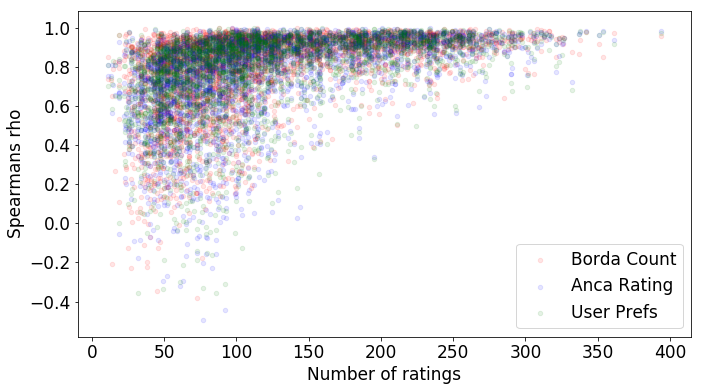

```python
ax = df.plot.scatter(x='numratings', y='borda_rho', color='red', alpha=0.1, label='Borda Count', figsize=(11,6)); df.plot.scatter(x='numratings', y='anca_rho', color='blue', alpha=0.1, label='Anca Rating', ax=ax); df.plot.scatter(x='numratings', y='prefs_rho', color='green', alpha=0.1, label='User Prefs', ax=ax); plt.xlabel('Number of ratings'); plt.ylabel('Spearmans rho')
```

## Top Rated has a big effect!

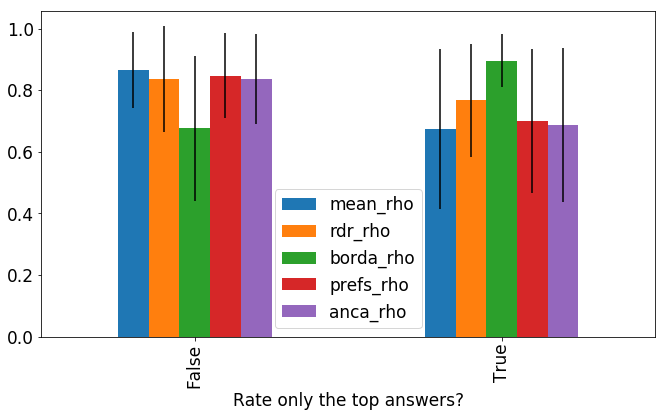

```python
fig, ax = plt.subplots(figsize=(11,6))
means.plot.bar(yerr=errors, ax=ax)
plt.xlabel('Rate only the top answers?')
```

## Borda count awards points for *being rated*

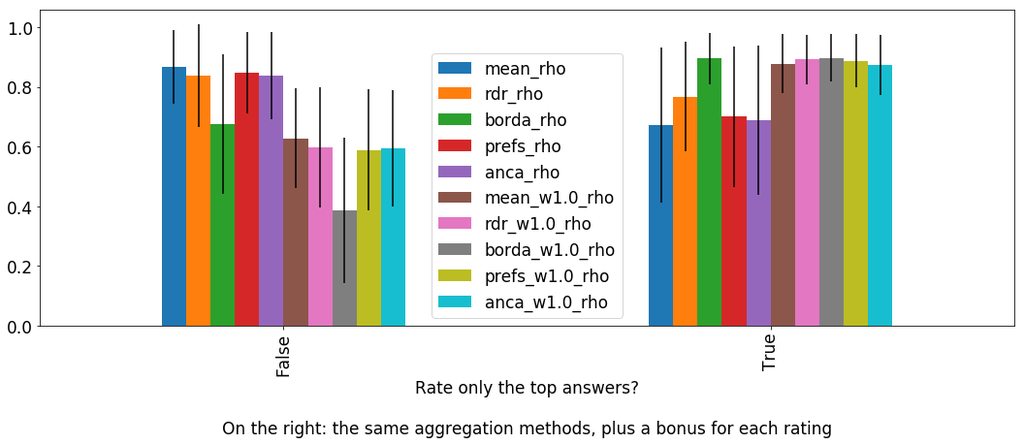

```python
fig, ax = plt.subplots(figsize=(18,6)); means.plot.bar(yerr=errors, ax=ax)
plt.xlabel('Rate only the top answers?\n\nOn the right: the same aggregation methods, plus a bonus for each rating')
```

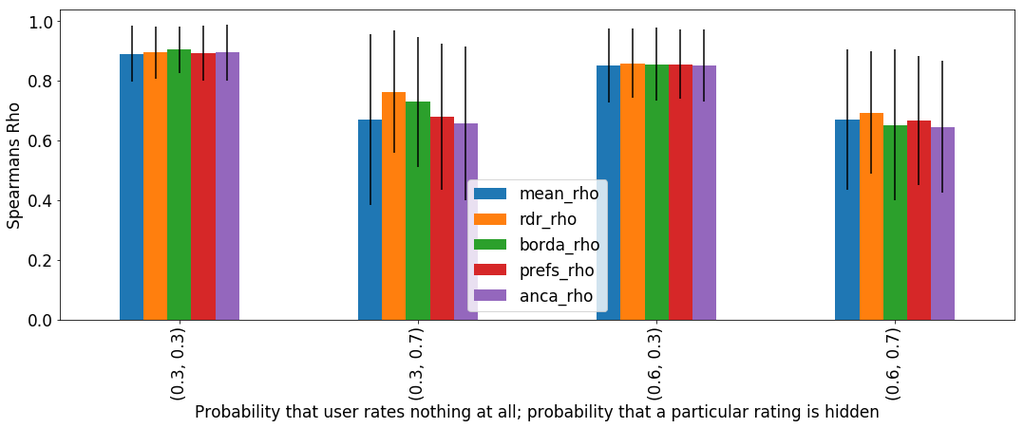

```python
fig, ax = plt.subplots(figsize=(18,6)); means.plot.bar(yerr=errors, ax=ax)
plt.xlabel('Probability that user rates nothing at all; probability that a particular rating is hidden')
plt.ylabel('Spearmans Rho')
```

## Probability that the best answer comes out on top

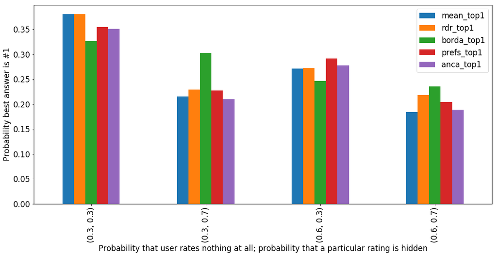

```python
fig, ax = plt.subplots(figsize=(18,8)); means.plot.bar(ax=ax); plt.xlabel('Probability that user rates nothing at all; probability that a particular rating is hidden'); plt.ylabel('Probability best answer is #1')
```

## Grouping by sparsity *and* toprated

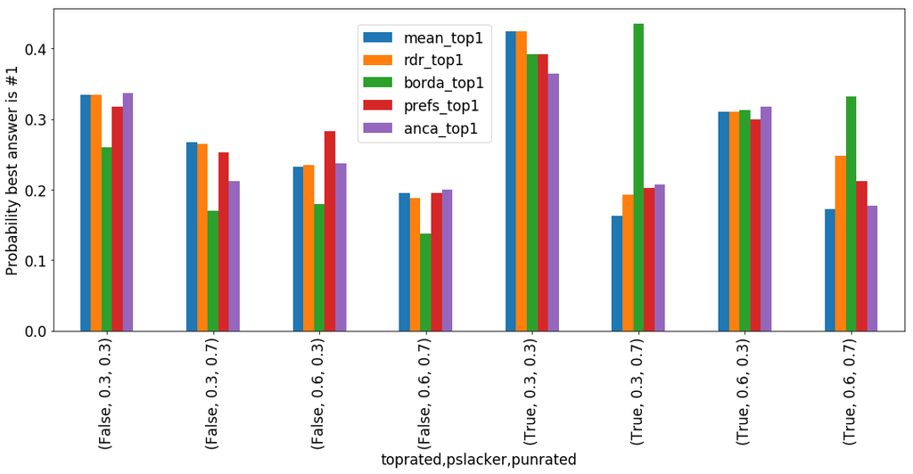

```python
fig, ax = plt.subplots(figsize=(18,7)); means.plot.bar(ax=ax); plt.legend(bbox_to_anchor=(0.53, 0.55), bbox_transform=plt.gcf().transFigure); plt.ylabel('Probability best answer is #1')
```

### Size of easiness bias has little if any effect

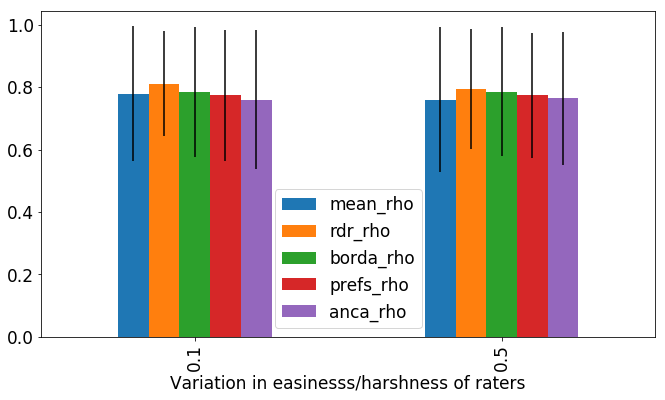

```python
fig, ax = plt.subplots(figsize=(11,6)); means.plot.bar(yerr=errors, ax=ax); plt.xlabel('Variation in easinesss/harshness of raters')
```

## When people are worse at rating, the aggregation methods do a little worse

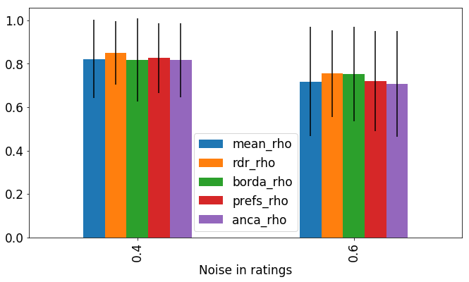

```python
fig, ax = plt.subplots(figsize=(11,6)); means.plot.bar(yerr=errors, ax=ax); plt.xlabel('Noise in ratings')
```

For some reason, Borda count is insensitive to sparsity; it only cares how many rows are in the matrix. The other methods are less sensitive to the size of the matrix but more sensitive to sparsity.